# Optimal Treatment Analysis

## Outcome Variable

**Outcome Variable:** whz

## Predictor Variables

**Intervention Variable:** vagbrth

**Adjustment Set:**

- arm
- sex
- W_mage
- meducyrs
- feducyrs
- hhwealth_quart
- W_mhtcm
- W_mwtkg
- W_mbmi
- single
- W_nrooms
- brthmon
- W_parity
- impfloor
- delta_W_mage
- delta_meducyrs
- delta_feducyrs
- delta_hhwealth_quart
- delta_W_mhtcm
- delta_W_mwtkg
- delta_W_mbmi
- delta_single
- delta_W_nrooms
- delta_brthmon
- delta_W_parity
- delta_impfloor

## Stratifying Variables

The analysis was stratified on these variable(s):

- agecat
- studyid
- country

## Data Summary

| agecat | studyid | country | vagbrth | n_cell | n |
| --- | --- | --- | --- | --- | --- |
| Birth | ki1000108-CMC-V-BCS-2002 | INDIA | 0 | 10 | 86 |
| Birth | ki1000108-CMC-V-BCS-2002 | INDIA | 1 | 76 | 86 |
| Birth | ki1000108-IRC | INDIA | 0 | 66 | 343 |
| Birth | ki1000108-IRC | INDIA | 1 | 277 | 343 |
| Birth | ki1017093b-PROVIDE | BANGLADESH | 0 | 108 | 532 |
| Birth | ki1017093b-PROVIDE | BANGLADESH | 1 | 424 | 532 |
| Birth | ki1017093c-NIH-Crypto | BANGLADESH | 0 | 184 | 465 |
| Birth | ki1017093c-NIH-Crypto | BANGLADESH | 1 | 281 | 465 |
| Birth | ki1119695-PROBIT | BELARUS | 0 | 1593 | 13830 |
| Birth | ki1119695-PROBIT | BELARUS | 1 | 12237 | 13830 |
| Birth | ki1126311-ZVITAMBO | ZIMBABWE | 0 | 1100 | 12814 |
| Birth | ki1126311-ZVITAMBO | ZIMBABWE | 1 | 11714 | 12814 |
| Birth | kiGH5241-JiVitA-3 | BANGLADESH | 0 | 500 | 17985 |
| Birth | kiGH5241-JiVitA-3 | BANGLADESH | 1 | 17485 | 17985 |
| Birth | kiGH5241-JiVitA-4 | BANGLADESH | 0 | 71 | 2395 |
| Birth | kiGH5241-JiVitA-4 | BANGLADESH | 1 | 2324 | 2395 |
| 6 months | ki1000108-CMC-V-BCS-2002 | INDIA | 0 | 25 | 368 |
| 6 months | ki1000108-CMC-V-BCS-2002 | INDIA | 1 | 343 | 368 |
| 6 months | ki1000108-IRC | INDIA | 0 | 68 | 408 |
| 6 months | ki1000108-IRC | INDIA | 1 | 340 | 408 |
| 6 months | ki1017093b-PROVIDE | BANGLADESH | 0 | 139 | 603 |
| 6 months | ki1017093b-PROVIDE | BANGLADESH | 1 | 464 | 603 |
| 6 months | ki1017093c-NIH-Crypto | BANGLADESH | 0 | 187 | 457 |
| 6 months | ki1017093c-NIH-Crypto | BANGLADESH | 1 | 270 | 457 |
| 6 months | ki1066203-TanzaniaChild2 | TANZANIA, UNITED REPUBLIC OF | 0 | 189 | 2004 |
| 6 months | ki1066203-TanzaniaChild2 | TANZANIA, UNITED REPUBLIC OF | 1 | 1815 | 2004 |
| 6 months | ki1119695-PROBIT | BELARUS | 0 | 1798 | 15758 |
| 6 months | ki1119695-PROBIT | BELARUS | 1 | 13960 | 15758 |
| 6 months | ki1126311-ZVITAMBO | ZIMBABWE | 0 | 721 | 8437 |
| 6 months | ki1126311-ZVITAMBO | ZIMBABWE | 1 | 7716 | 8437 |
| 6 months | kiGH5241-JiVitA-3 | BANGLADESH | 0 | 1075 | 16705 |
| 6 months | kiGH5241-JiVitA-3 | BANGLADESH | 1 | 15630 | 16705 |
| 6 months | kiGH5241-JiVitA-4 | BANGLADESH | 0 | 337 | 4056 |
| 6 months | kiGH5241-JiVitA-4 | BANGLADESH | 1 | 3719 | 4056 |
| 24 months | ki1000108-CMC-V-BCS-2002 | INDIA | 0 | 25 | 372 |
| 24 months | ki1000108-CMC-V-BCS-2002 | INDIA | 1 | 347 | 372 |
| 24 months | ki1000108-IRC | INDIA | 0 | 69 | 409 |
| 24 months | ki1000108-IRC | INDIA | 1 | 340 | 409 |
| 24 months | ki1017093b-PROVIDE | BANGLADESH | 0 | 137 | 579 |
| 24 months | ki1017093b-PROVIDE | BANGLADESH | 1 | 442 | 579 |
| 24 months | ki1017093c-NIH-Crypto | BANGLADESH | 0 | 99 | 260 |
| 24 months | ki1017093c-NIH-Crypto | BANGLADESH | 1 | 161 | 260 |
| 24 months | ki1066203-TanzaniaChild2 | TANZANIA, UNITED REPUBLIC OF | 0 | 2 | 6 |
| 24 months | ki1066203-TanzaniaChild2 | TANZANIA, UNITED REPUBLIC OF | 1 | 4 | 6 |
| 24 months | ki1119695-PROBIT | BELARUS | 0 | 463 | 3972 |
| 24 months | ki1119695-PROBIT | BELARUS | 1 | 3509 | 3972 |
| 24 months | ki1126311-ZVITAMBO | ZIMBABWE | 0 | 28 | 426 |
| 24 months | ki1126311-ZVITAMBO | ZIMBABWE | 1 | 398 | 426 |
| 24 months | kiGH5241-JiVitA-3 | BANGLADESH | 0 | 475 | 8555 |
| 24 months | kiGH5241-JiVitA-3 | BANGLADESH | 1 | 8080 | 8555 |
| 24 months | kiGH5241-JiVitA-4 | BANGLADESH | 0 | 323 | 4008 |
| 24 months | kiGH5241-JiVitA-4 | BANGLADESH | 1 | 3685 | 4008 |

The following strata were considered:

- agecat: 24 months, studyid: ki1000108-CMC-V-BCS-2002, country: INDIA
- agecat: 24 months, studyid: ki1000108-IRC, country: INDIA
- agecat: 24 months, studyid: ki1017093b-PROVIDE, country: BANGLADESH
- agecat: 24 months, studyid: ki1017093c-NIH-Crypto, country: BANGLADESH
- agecat: 24 months, studyid: ki1066203-TanzaniaChild2, country: TANZANIA, UNITED REPUBLIC OF
- agecat: 24 months, studyid: ki1119695-PROBIT, country: BELARUS
- agecat: 24 months, studyid: ki1126311-ZVITAMBO, country: ZIMBABWE
- agecat: 24 months, studyid: kiGH5241-JiVitA-3, country: BANGLADESH
- agecat: 24 months, studyid: kiGH5241-JiVitA-4, country: BANGLADESH
- agecat: 6 months, studyid: ki1000108-CMC-V-BCS-2002, country: INDIA
- agecat: 6 months, studyid: ki1000108-IRC, country: INDIA
- agecat: 6 months, studyid: ki1017093b-PROVIDE, country: BANGLADESH
- agecat: 6 months, studyid: ki1017093c-NIH-Crypto, country: BANGLADESH
- agecat: 6 months, studyid: ki1066203-TanzaniaChild2, country: TANZANIA, UNITED REPUBLIC OF
- agecat: 6 months, studyid: ki1119695-PROBIT, country: BELARUS
- agecat: 6 months, studyid: ki1126311-ZVITAMBO, country: ZIMBABWE
- agecat: 6 months, studyid: kiGH5241-JiVitA-3, country: BANGLADESH
- agecat: 6 months, studyid: kiGH5241-JiVitA-4, country: BANGLADESH
- agecat: Birth, studyid: ki1000108-CMC-V-BCS-2002, country: INDIA
- agecat: Birth, studyid: ki1000108-IRC, country: INDIA
- agecat: Birth, studyid: ki1017093b-PROVIDE, country: BANGLADESH
- agecat: Birth, studyid: ki1017093c-NIH-Crypto, country: BANGLADESH
- agecat: Birth, studyid: ki1119695-PROBIT, country: BELARUS
- agecat: Birth, studyid: ki1126311-ZVITAMBO, country: ZIMBABWE
- agecat: Birth, studyid: kiGH5241-JiVitA-3, country: BANGLADESH
- agecat: Birth, studyid: kiGH5241-JiVitA-4, country: BANGLADESH

### Dropped Strata

Some strata were dropped due to rare outcomes:

- agecat: 24 months, studyid: ki1066203-TanzaniaChild2, country: TANZANIA, UNITED REPUBLIC OF

## Methods Detail

We’re interested in the causal parameters $E[Y_a]$ for all values of $a \in \mathcal{A}$. These parameters represent the mean outcome if, possibly contrary to fact, we intervened to set all units to have $A=a$. Under the randomization and positivity assumptions, these are identified by the statistical parameters $\psi_a=E_W[E_{Y|A,W}(Y|A=a,W)]$. In addition, we’re interested in the mean of $Y$, $E[Y]$ under no intervention (the observed mean). We will estimate these parameters by using SuperLearner to fit the relevant likelihood factors – $E_{Y|A,W}(Y|A=a,W)$ and $p(A=a|W)$, and then updating our likelihood fit using a joint TMLE.

For unadjusted analyses ($W=\{\}$), initial likelihoods were estimated using Lrnr_glm to estimate the simple $E(Y|A)$ and Lrnr_mean to estimate $p(A)$. For adjusted analyses, a small library containing Lrnr_glmnet, Lrnr_xgboost, and Lrnr_mean was used.

Having estimated these parameters, we will then use the delta method to estimate relative risks and attributable risks relative to a prespecified baseline level of $A$.

# Results Detail

## Results Plots

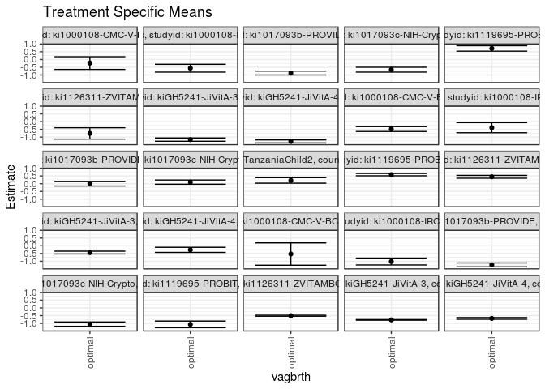

## Results Table

### Parameter: TSM

| agecat | studyid | country | intervention_level | baseline_level | estimate | ci_lower | ci_upper |
| --- | --- | --- | --- | --- | --- | --- | --- |
| Birth | ki1000108-CMC-V-BCS-2002 | INDIA | optimal | observed | -0.5337455 | -1.2570800 | 0.1895890 |
| Birth | ki1000108-IRC | INDIA | optimal | observed | -1.0172783 | -1.2388089 | -0.7957476 |
| Birth | ki1017093b-PROVIDE | BANGLADESH | optimal | observed | -1.2355710 | -1.3616802 | -1.1094619 |
| Birth | ki1017093c-NIH-Crypto | BANGLADESH | optimal | observed | -1.0482345 | -1.1869379 | -0.9095311 |
| Birth | ki1119695-PROBIT | BELARUS | optimal | observed | -1.0650002 | -1.2788804 | -0.8511200 |
| Birth | ki1126311-ZVITAMBO | ZIMBABWE | optimal | observed | -0.5062128 | -0.5375792 | -0.4748465 |
| Birth | kiGH5241-JiVitA-3 | BANGLADESH | optimal | observed | -0.7736862 | -0.7935925 | -0.7537799 |
| Birth | kiGH5241-JiVitA-4 | BANGLADESH | optimal | observed | -0.6794570 | -0.7327147 | -0.6261993 |
| 6 months | ki1000108-CMC-V-BCS-2002 | INDIA | optimal | observed | -0.4804307 | -0.6383821 | -0.3224794 |
| 6 months | ki1000108-IRC | INDIA | optimal | observed | -0.3918264 | -0.7180391 | -0.0656138 |
| 6 months | ki1017093b-PROVIDE | BANGLADESH | optimal | observed | 0.0004249 | -0.1508174 | 0.1516671 |
| 6 months | ki1017093c-NIH-Crypto | BANGLADESH | optimal | observed | 0.1017379 | -0.0335142 | 0.2369900 |
| 6 months | ki1066203-TanzaniaChild2 | TANZANIA, UNITED REPUBLIC OF | optimal | observed | 0.2120505 | 0.0339569 | 0.3901441 |
| 6 months | ki1119695-PROBIT | BELARUS | optimal | observed | 0.5852671 | 0.5103861 | 0.6601482 |
| 6 months | ki1126311-ZVITAMBO | ZIMBABWE | optimal | observed | 0.4460155 | 0.3530658 | 0.5389652 |
| 6 months | kiGH5241-JiVitA-3 | BANGLADESH | optimal | observed | -0.4392728 | -0.5291616 | -0.3493840 |
| 6 months | kiGH5241-JiVitA-4 | BANGLADESH | optimal | observed | -0.2624431 | -0.4275919 | -0.0972943 |
| 24 months | ki1000108-CMC-V-BCS-2002 | INDIA | optimal | observed | -0.2307220 | -0.6394436 | 0.1779997 |
| 24 months | ki1000108-IRC | INDIA | optimal | observed | -0.5606951 | -0.8128879 | -0.3085022 |
| 24 months | ki1017093b-PROVIDE | BANGLADESH | optimal | observed | -0.8733698 | -0.9997981 | -0.7469415 |
| 24 months | ki1017093c-NIH-Crypto | BANGLADESH | optimal | observed | -0.6559963 | -0.8138049 | -0.4981876 |
| 24 months | ki1119695-PROBIT | BELARUS | optimal | observed | 0.7149665 | 0.5398929 | 0.8900401 |
| 24 months | ki1126311-ZVITAMBO | ZIMBABWE | optimal | observed | -0.7629937 | -1.1292838 | -0.3967036 |
| 24 months | kiGH5241-JiVitA-3 | BANGLADESH | optimal | observed | -1.1646549 | -1.2702673 | -1.0590426 |
| 24 months | kiGH5241-JiVitA-4 | BANGLADESH | optimal | observed | -1.2812435 | -1.3802512 | -1.1822358 |

### Parameter: E(Y)

| agecat | studyid | country | intervention_level | baseline_level | estimate | ci_lower | ci_upper |
| --- | --- | --- | --- | --- | --- | --- | --- |
| Birth | ki1000108-CMC-V-BCS-2002 | INDIA | observed | observed | -0.4648256 | -0.7643210 | -0.1653302 |
| Birth | ki1000108-IRC | INDIA | observed | observed | -1.0105831 | -1.1973019 | -0.8238643 |
| Birth | ki1017093b-PROVIDE | BANGLADESH | observed | observed | -1.2984586 | -1.3752758 | -1.2216415 |
| Birth | ki1017093c-NIH-Crypto | BANGLADESH | observed | observed | -1.1549785 | -1.2577390 | -1.0522180 |
| Birth | ki1119695-PROBIT | BELARUS | observed | observed | -1.1448633 | -1.3544229 | -0.9353037 |
| Birth | ki1126311-ZVITAMBO | ZIMBABWE | observed | observed | -0.5168886 | -0.5428625 | -0.4909146 |
| Birth | kiGH5241-JiVitA-3 | BANGLADESH | observed | observed | -0.7774729 | -0.7964631 | -0.7584827 |
| Birth | kiGH5241-JiVitA-4 | BANGLADESH | observed | observed | -0.6890188 | -0.7414800 | -0.6365575 |
| 6 months | ki1000108-CMC-V-BCS-2002 | INDIA | observed | observed | -0.5026766 | -0.6536848 | -0.3516685 |
| 6 months | ki1000108-IRC | INDIA | observed | observed | -0.5989297 | -0.7344491 | -0.4634104 |
| 6 months | ki1017093b-PROVIDE | BANGLADESH | observed | observed | -0.1990907 | -0.2817968 | -0.1163845 |
| 6 months | ki1017093c-NIH-Crypto | BANGLADESH | observed | observed | 0.0515536 | -0.0469240 | 0.1500313 |
| 6 months | ki1066203-TanzaniaChild2 | TANZANIA, UNITED REPUBLIC OF | observed | observed | 0.0769382 | 0.0241090 | 0.1297674 |
| 6 months | ki1119695-PROBIT | BELARUS | observed | observed | 0.5792439 | 0.5193388 | 0.6391490 |
| 6 months | ki1126311-ZVITAMBO | ZIMBABWE | observed | observed | 0.3116179 | 0.2858347 | 0.3374010 |
| 6 months | kiGH5241-JiVitA-3 | BANGLADESH | observed | observed | -0.5935070 | -0.6130727 | -0.5739413 |
| 6 months | kiGH5241-JiVitA-4 | BANGLADESH | observed | observed | -0.3758037 | -0.4184544 | -0.3331531 |
| 24 months | ki1000108-CMC-V-BCS-2002 | INDIA | observed | observed | -0.5571505 | -0.6585247 | -0.4557763 |
| 24 months | ki1000108-IRC | INDIA | observed | observed | -0.7458150 | -0.8368180 | -0.6548120 |
| 24 months | ki1017093b-PROVIDE | BANGLADESH | observed | observed | -0.8928670 | -0.9755153 | -0.8102187 |
| 24 months | ki1017093c-NIH-Crypto | BANGLADESH | observed | observed | -0.8343077 | -0.9482310 | -0.7203844 |
| 24 months | ki1119695-PROBIT | BELARUS | observed | observed | 0.6874295 | 0.5756922 | 0.7991668 |
| 24 months | ki1126311-ZVITAMBO | ZIMBABWE | observed | observed | -1.1864319 | -1.2865891 | -1.0862748 |
| 24 months | kiGH5241-JiVitA-3 | BANGLADESH | observed | observed | -1.2983928 | -1.3216893 | -1.2750962 |
| 24 months | kiGH5241-JiVitA-4 | BANGLADESH | observed | observed | -1.2433658 | -1.2774681 | -1.2092634 |

### Parameter: PAR

| agecat | studyid | country | intervention_level | baseline_level | estimate | ci_lower | ci_upper |
| --- | --- | --- | --- | --- | --- | --- | --- |
| Birth | ki1000108-CMC-V-BCS-2002 | INDIA | optimal | observed | 0.0689199 | -0.5758445 | 0.7136843 |
| Birth | ki1000108-IRC | INDIA | optimal | observed | 0.0066952 | -0.1167734 | 0.1301638 |
| Birth | ki1017093b-PROVIDE | BANGLADESH | optimal | observed | -0.0628876 | -0.1717901 | 0.0460148 |
| Birth | ki1017093c-NIH-Crypto | BANGLADESH | optimal | observed | -0.1067440 | -0.2213717 | 0.0078837 |
| Birth | ki1119695-PROBIT | BELARUS | optimal | observed | -0.0798632 | -0.1817504 | 0.0220241 |
| Birth | ki1126311-ZVITAMBO | ZIMBABWE | optimal | observed | -0.0106757 | -0.0275263 | 0.0061748 |
| Birth | kiGH5241-JiVitA-3 | BANGLADESH | optimal | observed | -0.0037867 | -0.0093269 | 0.0017535 |
| Birth | kiGH5241-JiVitA-4 | BANGLADESH | optimal | observed | -0.0095618 | -0.0194778 | 0.0003543 |
| 6 months | ki1000108-CMC-V-BCS-2002 | INDIA | optimal | observed | -0.0222459 | -0.0579455 | 0.0134536 |
| 6 months | ki1000108-IRC | INDIA | optimal | observed | -0.2071033 | -0.5069274 | 0.0927208 |
| 6 months | ki1017093b-PROVIDE | BANGLADESH | optimal | observed | -0.1995155 | -0.3374561 | -0.0615749 |
| 6 months | ki1017093c-NIH-Crypto | BANGLADESH | optimal | observed | -0.0501843 | -0.1519048 | 0.0515361 |
| 6 months | ki1066203-TanzaniaChild2 | TANZANIA, UNITED REPUBLIC OF | optimal | observed | -0.1351123 | -0.3044501 | 0.0342254 |
| 6 months | ki1119695-PROBIT | BELARUS | optimal | observed | -0.0060233 | -0.0503961 | 0.0383496 |
| 6 months | ki1126311-ZVITAMBO | ZIMBABWE | optimal | observed | -0.1343976 | -0.2233380 | -0.0454573 |
| 6 months | kiGH5241-JiVitA-3 | BANGLADESH | optimal | observed | -0.1542342 | -0.2405316 | -0.0679369 |
| 6 months | kiGH5241-JiVitA-4 | BANGLADESH | optimal | observed | -0.1133607 | -0.2725104 | 0.0457890 |
| 24 months | ki1000108-CMC-V-BCS-2002 | INDIA | optimal | observed | -0.3264286 | -0.7214825 | 0.0686253 |
| 24 months | ki1000108-IRC | INDIA | optimal | observed | -0.1851199 | -0.4098251 | 0.0395853 |
| 24 months | ki1017093b-PROVIDE | BANGLADESH | optimal | observed | -0.0194972 | -0.1264857 | 0.0874913 |
| 24 months | ki1017093c-NIH-Crypto | BANGLADESH | optimal | observed | -0.1783114 | -0.3037028 | -0.0529201 |
| 24 months | ki1119695-PROBIT | BELARUS | optimal | observed | -0.0275370 | -0.1359567 | 0.0808828 |
| 24 months | ki1126311-ZVITAMBO | ZIMBABWE | optimal | observed | -0.4234382 | -0.7813155 | -0.0655609 |
| 24 months | kiGH5241-JiVitA-3 | BANGLADESH | optimal | observed | -0.1337378 | -0.2368738 | -0.0306018 |
| 24 months | kiGH5241-JiVitA-4 | BANGLADESH | optimal | observed | 0.0378777 | -0.0526723 | 0.1284278 |